# Quick Start Guide

## Introduction

Suppose you’ve developed a very useful algorithm or statistical model and you need to integrate it with some external system. Nowadays HTTP became de facto a lingua-franca for this kind of tasks.

In this article we will demonstrate how to use RestRserve to build a basic REST API.

## Workflow overview

Generally RestRserve workflow consists of several major steps:

1. Create application with `Application$new()`
2. Create a function which follows RestRserve API:
   - should take 2 arguments - `request` and `response` as an input. `request` and `response` are instances of `RestRserve::Request` and `RestRserve::Response`. It is **important to remember** that both `request` and `response` are **mutable** objects.
   - should modify `response` in place or `raise()` exception in case of error
3. Register this function as a handler for an endpoint
4. Start application

## 1. Create application

```r
library(RestRserve)
app = Application$new()
```

## 2. Define logic

For simplicity we will use Fibonacci number calculation as an algorithm we want to expose.

```r
calc_fib = function(n) {
  if (n < 0L) stop("n should be >= 0")
  if (n == 0L) return(0L)
  if (n == 1L || n == 2L) return(1L)
  x = rep(1L, n)

  for (i in 3L:n) {
   x[[i]] = x[[i - 1]] + x[[i - 2]]
  }

  return(x[[n]])
}
```

Create function which will handle requests.

```r
fib_handler = function(.req, .res) {
  n = as.integer(.req$parameters_query[["n"]])
  if (length(n) == 0L || is.na(n)) {
    raise(HTTPError$bad_request())
  }
  .res$set_body(as.character(calc_fib(n)))
  .res$set_content_type("text/plain")
}
```

You may have noticed strange `.req` and `.res` argument names. Starting from `RestRserve` v0.4.0 these “reserved” names allows to benefit from autocomplete:

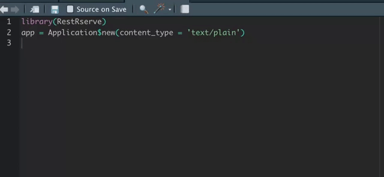

Technically `.req` and `.res` are just empty instances of `?Request` and `?Response` classes exported by `RestRserve` in order to make autocomplete work.

## 2. Register endpoint

```r
app$add_get(path = "/fib", FUN = fib_handler)
```

## 3. Test endpoints

Now we can test our application without starting it:

```r
request = Request$new(path = "/fib", parameters_query = list(n = 10))
response = app$process_request(request)

cat("Response status:", response$status)
```

```
#> Response status: 200 OK
```

```r
cat("Response body:", response$body)
```

```
#> Response body: 55
```

It is generally a good idea to write unit tests against application. One can use a common framework such as tinytest.

## 4. Add OpenAPI description and Swagger UI

Generally it is a good idea to provide documentation along with the API. Convenient way to do that is to supply a [openapi specification](https://swagger.io/docs/specification/about/). This as simple as adding a yaml file as an additional endpoint:

```yaml
openapi: 3.0.1
info:
  title: RestRserve OpenAPI
  version: '1.0'
servers:
  - url: /
paths:
  /fib:
    get:
      description: Calculates Fibonacci number
      parameters:
        - name: "n"
          description: "x for Fibonnacci number"
          in: query
          schema:
            type: integer
          example: 10
          required: true
      responses:
        200:
          description: API response
          content:
            text/plain:
              schema:
                type: string
                example: 5
        400:
          description: Bad Request
```

```r
yaml_file = system.file("examples", "openapi", "openapi.yaml", package = "RestRserve")
app$add_openapi(path = "/openapi.yaml", file_path = yaml_file)
app$add_swagger_ui(path = "/doc", path_openapi = "/openapi.yaml", use_cdn = TRUE)
```

## 5. Start the app

Now all is ready and we can start application with Rserve backend. It will block R session and start listening for incoming requests.

```r
backend = BackendRserve$new()
backend$start(app, http_port = 8080)
```

## 6. Test it

Send request to calculate fibonacci number:

```bash
curl localhost:8080/fib?n=10
```

Check out a swagger UI in the browser: `http://localhost:8080/doc`